# N741 Spring 2018 - Homework 7

### **PROBLEM 6: Fit a Classification Tree for MCS < 45**

Use the `rpart` package to fit a classification tree to the poor mental health indicator `mcs_lt45`.

```r
fitk <- rpart::rpart(mcs_lt45 ~ age + female + pss_fr +
                       homeless + pcs + cesd,
                     method = "class", data = h1)
class(fitk)
```

```
## [1] "rpart"
```

```r
# Display the results
rpart::printcp(fitk)
```

```
##
## Classification tree:
## rpart::rpart(formula = mcs_lt45 ~ age + female + pss_fr + homeless +
##     pcs + cesd, data = h1, method = "class")
##
## Variables actually used in tree construction:
## [1] age  cesd pcs
##
## Root node error: 84/453 = 0.18543
##
## n= 453
##
##         CP nsplit rel error  xerror     xstd
## 1 0.136905      0   1.00000 1.00000 0.098475
## 2 0.065476      2   0.72619 0.83333 0.091584
## 3 0.017857      4   0.59524 0.80952 0.090502
## 4 0.010000      6   0.55952 0.75000 0.087675
```

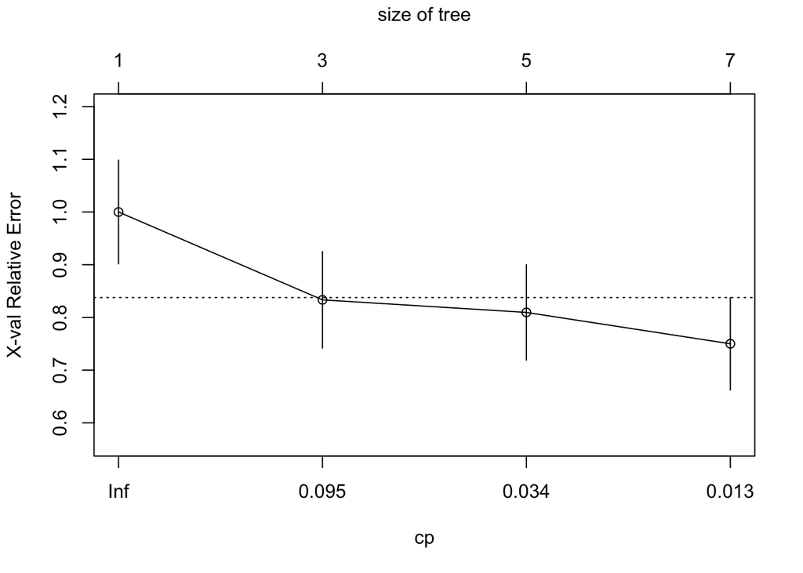

```r
#Visualize the cross-validation results
rpart::plotcp(fitk)
```

```r
# Get a detailed summary of the splits
summary(fitk)
```

```
## Call:
## rpart::rpart(formula = mcs_lt45 ~ age + female + pss_fr + homeless +
##     pcs + cesd, data = h1, method = "class")
##   n= 453
##
##           CP nsplit rel error    xerror       xstd
## 1 0.13690476      0 1.0000000 1.0000000 0.09847465
## 2 0.06547619      2 0.7261905 0.8333333 0.09158409
## 3 0.01785714      4 0.5952381 0.8095238 0.09050164
## 4 0.01000000      6 0.5595238 0.7500000 0.08767468
##
## Variable importance
##   cesd    pcs    age pss_fr
##     76     16      6      2
##
## Node number 1: 453 observations,    complexity param=0.1369048
##   predicted class=1  expected loss=0.1854305  P(node) =1
##     class counts:    84   369
##    probabilities: 0.185 0.815
##   left son=2 (113 obs) right son=3 (340 obs)
##   Primary splits:
##       cesd   < 24.5     to the left,  improve=35.952730, (0 missing)
##       pcs    < 49.46132 to the right, improve= 7.907014, (0 missing)
##       pss_fr < 10.5     to the right, improve= 4.386206, (0 missing)
##       female < 0.5      to the left,  improve= 1.504589, (0 missing)
##       age    < 48.5     to the right, improve= 1.425056, (0 missing)
##   Surrogate splits:
##       age < 57.5     to the right, agree=0.753, adj=0.009, (0 split)
##       pcs < 70.77019 to the right, agree=0.753, adj=0.009, (0 split)
##
## Node number 2: 113 observations,    complexity param=0.1369048
##   predicted class=0  expected loss=0.4690265  P(node) =0.2494481
##     class counts:    60    53
##    probabilities: 0.531 0.469
##   left son=4 (29 obs) right son=5 (84 obs)
##   Primary splits:
##       cesd   < 11.5     to the left,  improve=10.427690, (0 missing)
##       pcs    < 60.7539  to the left,  improve= 8.921666, (0 missing)
##       pss_fr < 11.5     to the right, improve= 2.105364, (0 missing)
##       female < 0.5      to the left,  improve= 1.591788, (0 missing)
```

[output cut: 83 more lines]

```
##       homeless < 0.5      to the right, improve=0.1000000, (0 missing)
##   Surrogate splits:
##       pss_fr < 7        to the left,  agree=0.80, adj=0.429, (0 split)
##       age    < 45       to the right, agree=0.75, adj=0.286, (0 split)
##       pcs    < 57.34769 to the right, agree=0.75, adj=0.286, (0 split)
##
## Node number 82: 7 observations
##   predicted class=0  expected loss=0.1428571  P(node) =0.01545254
##     class counts:     6     1
##    probabilities: 0.857 0.143
##
## Node number 83: 13 observations
##   predicted class=1  expected loss=0.3846154  P(node) =0.02869757
##     class counts:     5     8
##    probabilities: 0.385 0.615
```

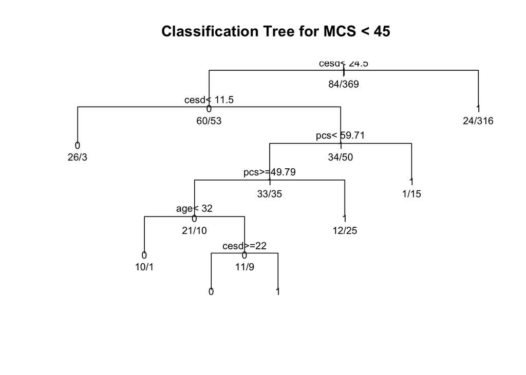

```r
# Plot the tree
plot(fitk, uniform = TRUE,
     main = "Classification Tree for MCS < 45 ")
text(fitk, use.n = TRUE, all = TRUE, cex = 0.8)
```

### **PROBLEM 7: Fit a Conditional Classification Tree for MCS < 45**

Using the `party` package, we can fit a conditional classification tree using the `ctree()` function. Let’s do one for the indicator of depression `mcs_lt45` given the other variables in the `h1` dataset: `age`, `female`, `pss_fr`, `homeless`, `pcs`, `cesd`.

```r
# look at mcs_lt45 with ctree from party
fitallpk <- party::ctree(mcs_lt45 ~ age + female + pss_fr +
                           homeless + pcs + cesd, data = h1)
class(fitallpk)
```

```
## [1] "BinaryTree"
## attr(,"package")
## [1] "party"
```

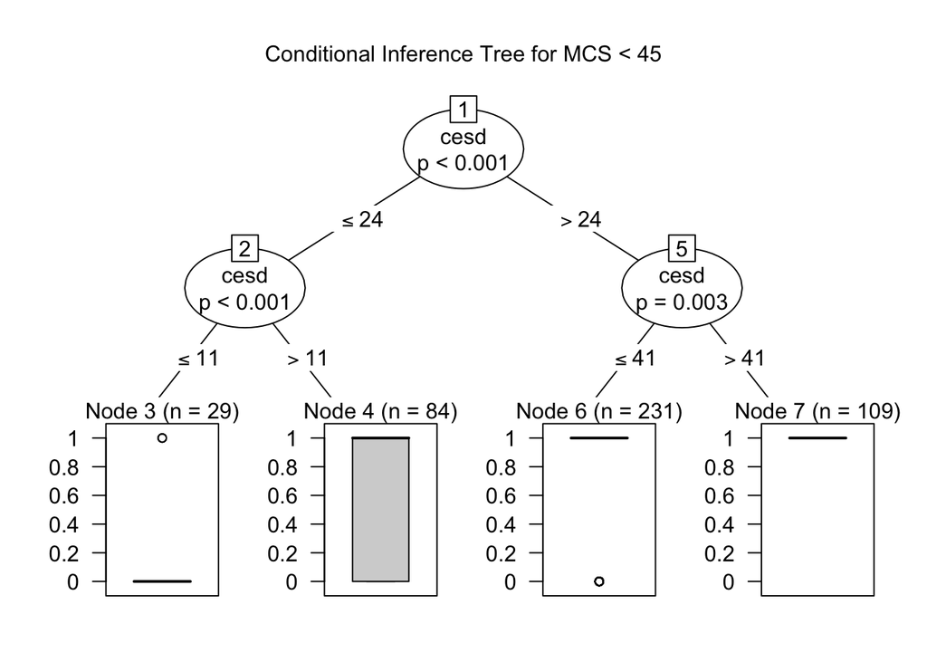

```r
plot(fitallpk, main = "Conditional Inference Tree for MCS < 45")
```

### **PROBLEM 8: Recursive Partitioning of Classification Tree for MCS < 45**

Using the code above to do recursive partitioning of MCS < 45 (`mcs_lt45`) on `age`, `female`, `pss_fr`, `homeless`, `pcs`, `cesd`. Also use the `partykit` package to get prettier graphics for this classification tree.

```r
# Recursive partitioning of MCS < 45 on age,
# female, pss_fr, homeless, pcs, cesd
WhoHasPoorMentalHealth <- rpart::rpart(mcs_lt45 ~ age + female +
                                 pss_fr + homeless + pcs + cesd,
                               data = h1,
                               control = rpart.control(cp = 0.001,
                                                       minbucket = 20))

WhoHasPoorMentalHealth
```

```
## n= 453
##
## node), split, n, deviance, yval
##       * denotes terminal node
##
##  1) root 453 68.423840 0.8145695
##    2) cesd< 24.5 113 28.141590 0.4690265
##      4) cesd< 11.5 29  2.689655 0.1034483 *
##      5) cesd>=11.5 84 20.238100 0.5952381
##       10) pcs< 59.00035 64 15.937500 0.5312500
##         20) pcs>=49.7901 27  6.000000 0.3333333 *
##         21) pcs< 49.7901 37  8.108108 0.6756757 *
##       11) pcs>=59.00035 20  3.200000 0.8000000 *
##    3) cesd>=24.5 340 22.305880 0.9294118
##      6) cesd< 41.5 231 21.506490 0.8961039
##       12) pss_fr>=10.5 52  8.076923 0.8076923 *
##       13) pss_fr< 10.5 179 12.905030 0.9217877
##         26) pcs>=50.23704 80  8.750000 0.8750000
##           52) pcs< 54.12466 25  4.560000 0.7600000 *
##           53) pcs>=54.12466 55  3.709091 0.9272727 *
##         27) pcs< 50.23704 99  3.838384 0.9595960
##           54) pss_fr>=4.5 55  3.709091 0.9272727 *
##           55) pss_fr< 4.5 44  0.000000 1.0000000 *
##      7) cesd>=41.5 109  0.000000 1.0000000 *
```

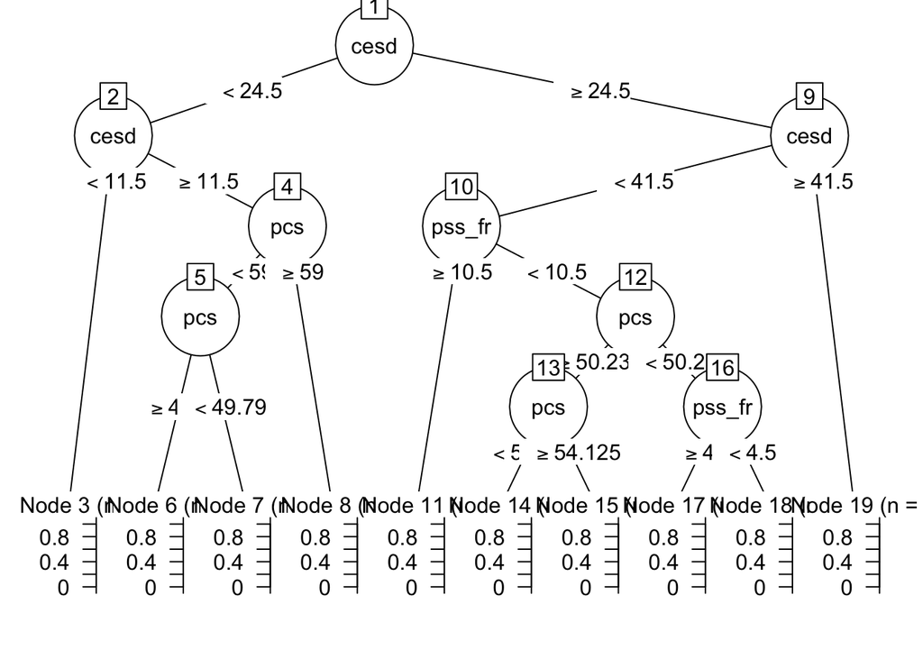

```r
library(partykit)
# Plot the tree
plot(partykit::as.party(WhoHasPoorMentalHealth))
```

### **EXTRA CREDIT Scatterplot of recursive partitions for MCS < 45 for PCS and CESD**

Using the code above, create a scatterplot of `pcs` and `cesd` where the points are colored by the indication of poor mental health `mcs_lt45`. Play with the `geom_vline()` or `geom_hline()` or `geom_segment()` to insert lines that best separate subjects with poor mental health (MCS < 45) from those with normal to better than average mental health (MCS > 45).

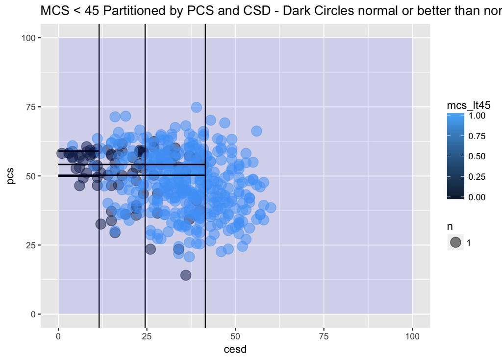

```r
# Graph as partition
# using the break points shown from the
# conditional tree
ggplot(data = h1, aes(x = cesd, y = pcs)) +
  geom_count(aes(color = mcs_lt45), alpha = 0.5) +
  geom_vline(xintercept = 24.5) +
  geom_vline(xintercept = 11.5) +
  geom_vline(xintercept = 41.5) +
  geom_segment(x = 11.5, xend = 0, y = 59.00035, yend = 59.00035) +
  geom_segment(x = 11.5, xend = 0, y = 49.7901, yend = 49.7901) +
  geom_segment(x = 41.5, xend = 0, y = 50.23704, yend = 50.23704) +
  geom_segment(x = 41.5, xend = 0, y = 54.12466, yend = 54.12466)+
  annotate("rect", xmin = 0, xmax = 100, ymin = 0, ymax = 100, fill = "blue", alpha = 0.1) +
  ggtitle("MCS < 45 Partitioned by PCS and CSD - Dark Circles normal or better than normal mental health")
```

### **PROBLEM 9: Fit a Random Forest Model for MCS**

Now let’s use a Random Forest approach for modeling the MCS by the other variables in the dataset:

- `age`
- `female`
- `pss_fr`
- `homeless`
- `pcs`
- `cesd`

Use the code above to fit the model and explore how well the model converges and how well it does predicting MCS scores.

```r
h1 <- as.data.frame(h1)
set.seed(131)
# Random Forest for the h1 dataset
fitallrf <- randomForestSRC::rfsrc(mcs_lt45 ~ age + female +
                                     pss_fr + homeless + pcs + cesd,
                                   data = h1, ntree = 100,
                                   tree.err=TRUE)
# view the results
fitallrf
```

```
##                          Sample size: 453
##                      Number of trees: 100
##            Forest terminal node size: 5
##        Average no. of terminal nodes: 38.69
## No. of variables tried at each split: 2
##               Total no. of variables: 6
##                             Analysis: RF-R
##                               Family: regr
##                       Splitting rule: mse
##                 % variance explained: 32.69
##                           Error rate: 0.1
```

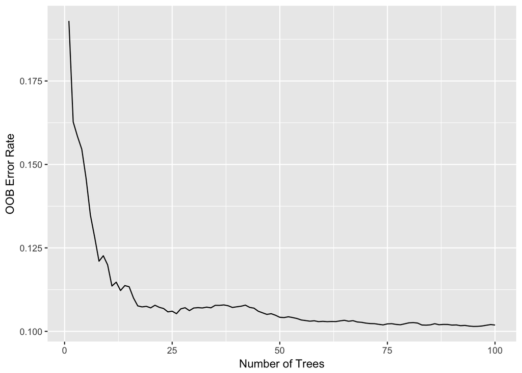

```r
gg_e <- ggRandomForests::gg_error(fitallrf)
plot(gg_e)
```

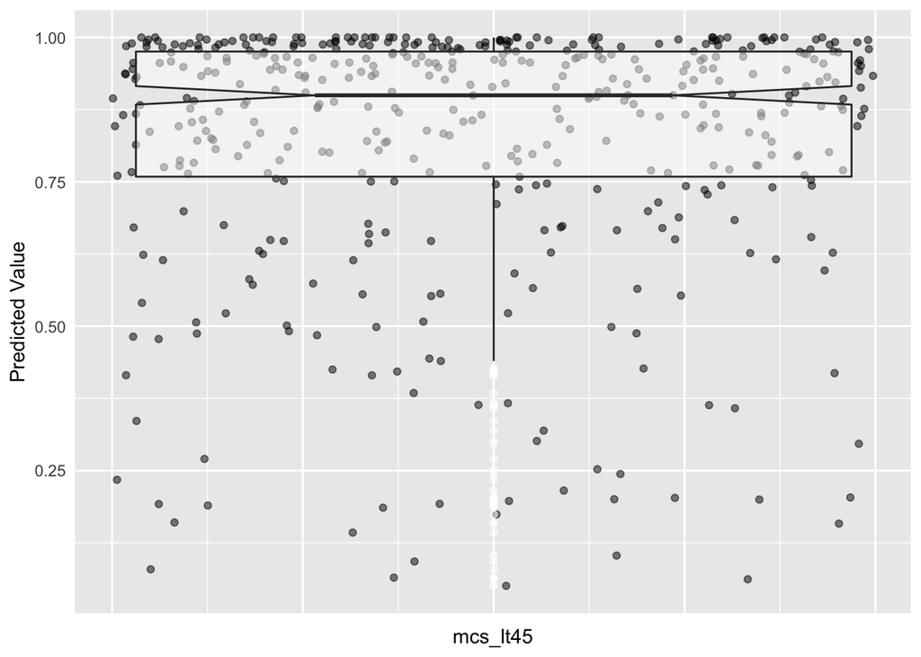

```r
# Plot the predicted cesd values
plot(ggRandomForests::gg_rfsrc(fitallrf), alpha = 0.5)
```

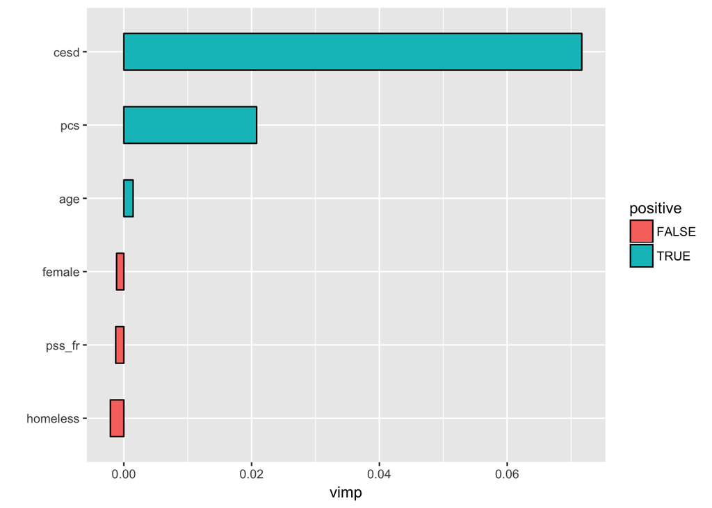

```r
# Plot the VIMP rankins of independent variables
plot(ggRandomForests::gg_vimp(fitallrf))
```

```r
# Select the variables
varsel_cesd <- randomForestSRC::var.select(fitallrf)
```

```
## minimal depth variable selection ...
##
##
## -----------------------------------------------------------
## family             : regr
## var. selection     : Minimal Depth
## conservativeness   : medium
## x-weighting used?  : TRUE
## dimension          : 6
## sample size        : 453
## ntree              : 100
## nsplit             : 0
## mtry               : 2
## nodesize           : 5
## refitted forest    : FALSE
## model size         : 6
## depth threshold    : 4.557
## PE (true OOB)      : 0.1019
##
##
## Top variables:
##          depth vimp
## pcs       1.24   NA
## cesd      1.29   NA
## pss_fr    1.82   NA
## age       1.86   NA
## female    3.82   NA
## homeless  4.02   NA
## -----------------------------------------------------------
```

```r
glimpse(varsel_cesd)
```

```
## List of 6
##  $ err.rate       : num 0.102
##  $ modelsize      : int 6
##  $ topvars        : chr [1:6] "pcs" "cesd" "pss_fr" "age" ...
##  $ varselect      :'data.frame': 6 obs. of  2 variables:
##   ..$ depth: num [1:6] 1.24 1.29 1.82 1.86 3.82 4.02
##   ..$ vimp : num [1:6] NA NA NA NA NA NA
##  $ rfsrc.refit.obj: NULL
##  $ md.obj         :List of 11
##   ..$ order                 : num [1:6, 1:2] 1.86 3.82 1.82 4.02 1.24 1.29 4.27 7.63 5.66 7.47 ...
##   .. ..- attr(*, "dimnames")=List of 2
##   ..$ count                 : Named num [1:6] 0.1772 0.0918 0.1494 0.1019 0.1482 ...
##   .. ..- attr(*, "names")= chr [1:6] "age" "female" "pss_fr" "homeless" ...
##   ..$ nodes.at.depth        : num [1:10000, 1:100] 2 3 6 8 10 8 5 2 0 NA ...
##   ..$ sub.order             : NULL
##   ..$ threshold             : num 4.56
##   ..$ threshold.1se         : num 4.69
##   ..$ topvars               : chr [1:6] "age" "female" "pss_fr" "homeless" ...
##   ..$ topvars.1se           : chr [1:6] "age" "female" "pss_fr" "homeless" ...
##   ..$ percentile            : Named num [1:6] 0.179 0.382 0.183 0.4 0.124 ...
##   .. ..- attr(*, "names")= chr [1:6] "age" "female" "pss_fr" "homeless" ...
##   ..$ density               : Named num [1:15] 0.0693 0.0998 0.1255 0.129 0.1133 ...
##   .. ..- attr(*, "names")= chr [1:15] "0" "1" "2" "3" ...
##   ..$ second.order.threshold: num 7.05
```

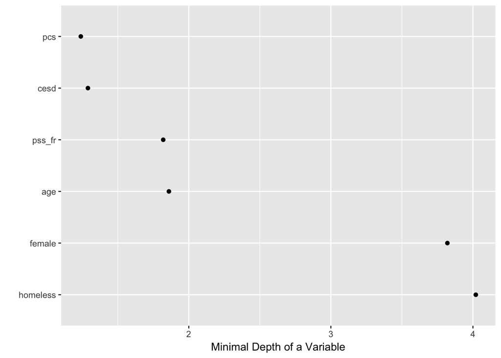

```r
# Save the gg_minimal_depth object for later use
gg_md <- ggRandomForests::gg_minimal_depth(varsel_cesd)
# Plot the object
plot(gg_md)
```

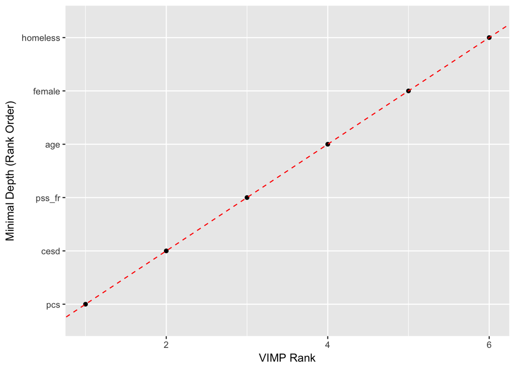

```r
# Plot minimal depth v VIMP
gg_mdVIMP <- ggRandomForests::gg_minimal_vimp(gg_md)
plot(gg_mdVIMP)
```

Using the code above, see how well each variable predicts MCS scores given the other variables in the dataset `h1`.

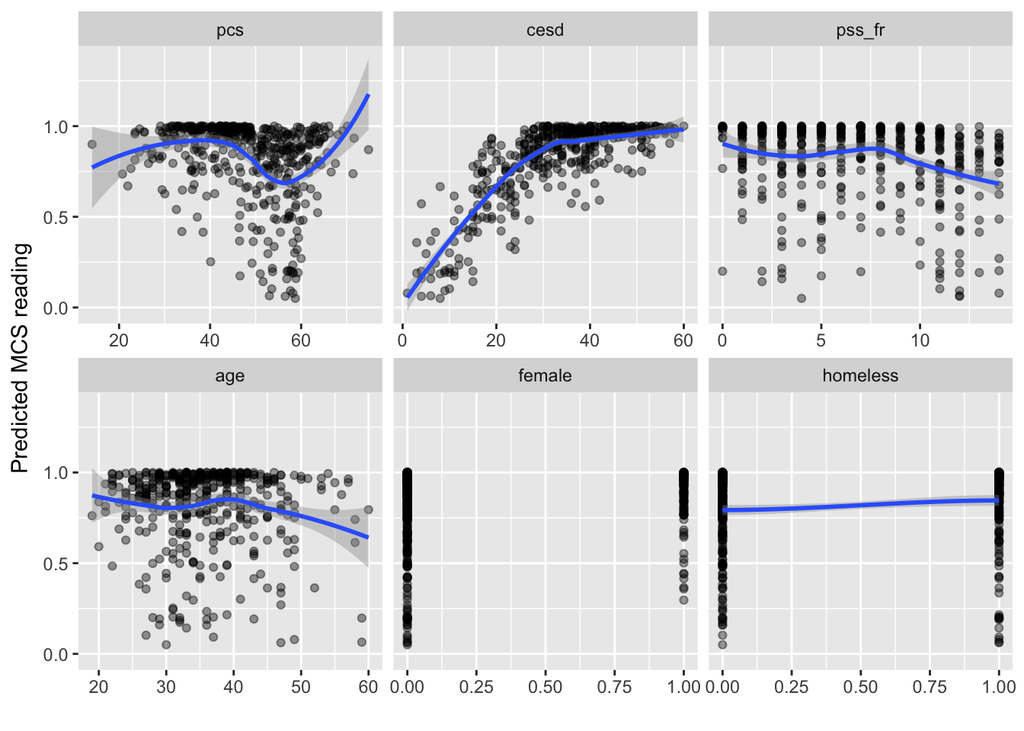

```r
#Create the variable dependence object from the random forest
gg_v <- ggRandomForests::gg_variable(fitallrf)

# Use the top ranked minimal depth variables only, plotted in minimal depth rank order
xvar <- gg_md$topvars

# Plot the variable list in a single panel plot
plot(gg_v, xvar = xvar, panel = TRUE, alpha = 0.4) +
  labs(y="Predicted MCS reading", x="")
```

The github repository for this assignment can be accessed via this link (https://github.com/RosemaryKinuthia/N741Spring2018_Homework7.git)[https://github.com/RosemaryKinuthia/N741Spring2018_Homework7.git]